# Covid-19 topic page: Search bounces

## Background

Idea: journeys that go ‘search->page->search’ suggest that the page didn’t meet the need. What pages have the highest proportion of such journeys?

1. Sample all GOV.UK journeys
2. Find pages that occur between searches ‘search->page->search’
3. Find pages that occur after a search, but don’t lead to a search: ‘search->page->page’ or ‘search->page->end’
4. Per page, calculate the ratio of (1) to (2)

[Trello card](https://trello.com/c/Y9WScpCJ/9-what-pages-have-search-bounces-on-all-govuk)

## Data

### Data caveats

Sessions aren’t randomly sampled, we just take the first n that Google BigQuery gives us.

### Web analytics

You need access to the BigQuery table `govuk-xgov.InsightsDataset.corona_journeys_20200322`. This holds every page visited by any session that included the coronavirus topic page `https://www.gov.uk/government/topical-events/coronavirus-covid-19-uk-government-response`.

## Load packages

```r
# Title for graphs
title <- "Coronavirus search bounces"
```

```r
# General
library(tidyverse)
```

```r
# Format to a string to the nearest 1%
one_percent <- partial(scales::percent, accuracy = 1)
```

## Download data from BigQuery

Create a dataset called `sessions_raw`. It’s called `raw` because it needs a lot of cleaning.

```r
# Authenticate via the browser (using your own email address)
bigrquery::bq_auth(email = "duncan.garmonsway@digital.cabinet-office.gov.uk")

# Connect to the dataset
con <- DBI::dbConnect(bigrquery::bigquery(),
                      project = "govuk-xgov",
                      dataset = "InsightsDataset")

# Query a table
sql <-
'
  WITH sample AS (
    SELECT DISTINCT session_id
    FROM `govuk-xgov.InsightsDataset.corona_journeys_20200322`
    -- WHERE visitStartTimestamp >= TIMESTAMP "2020-03-22 00:00:00 UTC"
    -- AND visitStartTimestamp < TIMESTAMP "2020-03-23 00:00:00 UTC"
    LIMIT 100000
  )
  SELECT
    main.session_id,
    main.pagePath AS page,
    main.event_start_time AS date_time
  FROM
    `govuk-xgov.InsightsDataset.corona_journeys_20200322` AS main
  INNER JOIN sample ON sample.session_id = main.session_id
'
# Perform the query
sessions_raw <- DBI::dbGetQuery(con, sql)
```

```
Complete
```

```
Billed: 0 B
```

```
Downloading 311,378 rows in 32 pages.
```

[output not shown]

[output cut: 11 more lines]

## Find pages following/preceding search

A search URL looks like `https://www.gov.uk/search/all?keywords=coronavirus&order=relevance`.

```r
searches <-
  sessions_raw %>%
  mutate(is_search = str_sub(page, 1, 18) == "www.gov.uk/search/") %>%
  group_by(session_id) %>%
  arrange(session_id, date_time) %>%
  mutate(after_search = lag(is_search, default = FALSE),
         before_search = lead(is_search, default = FALSE),
         bounced_back = lead(page, default = "") == lag(page, default = ""),
         between_same_search = after_search & before_search & bounced_back) %>%
  ungroup()
```

How many pages were viewed

- `after_search` = after a search
- `before_search` = before a search
- `bounced_back` = bounced back to the previous page (not necessarily a search)
- `between_same_search` = bounced back to the previous search

```r
# Frequencies
frequencies <-
  searches %>%
  keep(is.logical) %>%
  map(table)

frequencies
```

```
$is_search

 FALSE   TRUE
303975   7403

$after_search

 FALSE   TRUE
304728   6650

$before_search

 FALSE   TRUE
304340   7038

$bounced_back

 FALSE   TRUE
225657  85721

$between_same_search

 FALSE   TRUE
310664    714
```

```r
# Percentages
frequencies %>%
  map(prop.table) %>%
  map_depth(2, one_percent)
```

```
$is_search
$is_search$`FALSE`
[1] "98%"

$is_search$`TRUE`
[1] "2%"


$after_search
$after_search$`FALSE`
[1] "98%"

$after_search$`TRUE`
[1] "2%"


$before_search
$before_search$`FALSE`
[1] "98%"

$before_search$`TRUE`
[1] "2%"


$bounced_back
$bounced_back$`FALSE`
[1] "72%"

$bounced_back$`TRUE`
[1] "28%"


$between_same_search
$between_same_search$`FALSE`
[1] "100%"

$between_same_search$`TRUE`
[1] "0%"
```

```
98%
```

```
2%
```

```
98%
```

```
2%
```

```
98%
```

```
2%
```

```
72%
```

```
28%
```

```
100%
```

```
0%
```

## Bounce-back rates per page (not necessarily search)

```r
bounce_back_rates <-
  searches %>%
  group_by(session_id) %>%
  mutate(bounced_back = lead(bounced_back, default = FALSE)) %>%
  ungroup() %>%
  count(page, bounced_back) %>%
  complete(page, bounced_back, fill = list(n = 0)) %>%
  pivot_wider(id = page,
              names_from = bounced_back,
              names_prefix = "bounced_",
              values_from = n) %>%
  mutate(rate = bounced_TRUE / (bounced_TRUE + bounced_FALSE))
```

Graph the distribution of rates, filtering for pages that are visited at least 100 times.

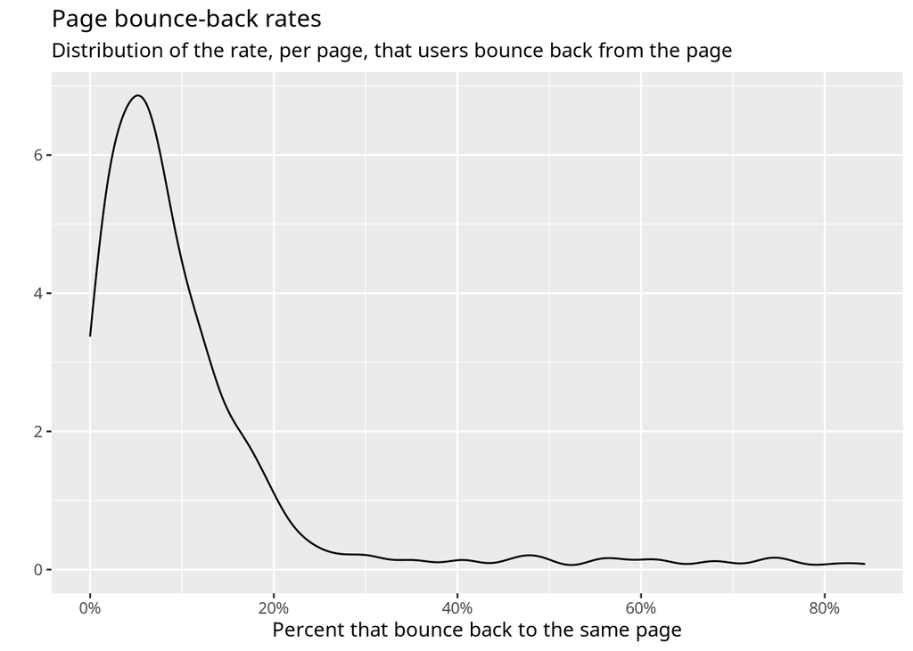

```r
bounce_back_rates %>%
  filter(bounced_FALSE + bounced_TRUE >= 100) %>%
  ggplot(aes(rate)) +
  geom_density() +
  scale_x_continuous(labels = one_percent) +
  labs(x = "Percent that bounce back to the same page",
       y = "",
       title = "Page bounce-back rates",
       subtitle = "Distribution of the rate, per page, that users bounce back from the page")
```

```r
bounce_back_rates %>%
  filter(bounced_FALSE + bounced_TRUE >= 100) %>%
  arrange(desc(rate))
```

| page | bounced_FALSE | bounced_TRUE | rate |
| --- | --- | --- | --- |
| /am-i-getting-minimum-wage | 24 | 129 | 0.843137255 |
| /student-finance-calculator | 19 | 81 | 0.810000000 |
| /calculate-statutory-sick-pay | 95 | 305 | 0.762500000 |
| /pay-leave-for-parents | 35 | 100 | 0.740740741 |
| /calculate-your-holiday-entitlement | 45 | 127 | 0.738372093 |
| /calculate-your-redundancy-pay | 47 | 104 | 0.688741722 |
| /check-if-you-need-tax-return | 69 | 141 | 0.671428571 |
| /state-pension-age | 63 | 104 | 0.622754491 |
| www.student-finance.service.gov.uk/customer/apply/ft/2021/pages/currentcourseandfees.xhtml/coursechoicequestion | 48 | 76 | 0.612903226 |
| /check-uk-visa | 117 | 164 | 0.583629893 |

[output cut: 299 more lines]

## Search-bounce-back rates per search

```r
search_bounce_back_rates <-
  searches %>%
  group_by(session_id) %>%
  mutate(bounced_back = lead(bounced_back, default = FALSE)) %>%
  ungroup() %>%
  filter(is_search) %>%
  mutate(page = str_sub(page, 19)) %>%
  count(page, bounced_back) %>%
  complete(page, bounced_back, fill = list(n = 0)) %>%
  pivot_wider(id = page,
              names_from = bounced_back,
              names_prefix = "bounced_",
              values_from = n) %>%
  mutate(rate = bounced_TRUE / (bounced_TRUE + bounced_FALSE))
```

Only a few pages are in this category.

```r
search_bounce_back_rates %>%
  filter(bounced_FALSE + bounced_TRUE >= 100)
```

| page | bounced_FALSE | bounced_TRUE | rate |
| --- | --- | --- | --- |
| all?keywords=universal+credit&order=relevance | 102 | 4 | 0.03773585 |
| all?order=updated-newest&page=2&topical_events[]=coronavirus-covid-19-uk-government-response | 105 | 15 | 0.12500000 |
| all?topical_events[]=coronavirus-covid-19-uk-government-response&order=updated-newest | 657 | 70 | 0.09628611 |
| news-and-communications | 116 | 24 | 0.17142857 |
| news-and-communications?page=2&topical_events[]=coronavirus-covid-19-uk-government-response | 135 | 30 | 0.18181818 |
| news-and-communications?topical_events[]=coronavirus-covid-19-uk-government-response | 841 | 167 | 0.16567460 |

Look at one of the worst `gov.uk/news-and-communications?topical_events[]=coronavirus-covid-19-uk-government-response`.

It turns out that search is linked to via `News` on the topic page. People are scrolling through to visit all the news items. The other searches are similar, apart from Universal Credit.

```r
sessions_raw %>%
  filter(page == "www.gov.uk/search/news-and-communications?topical_events[]=coronavirus-covid-19-uk-government-response") %>%
  distinct(session_id) %>%
  semi_join(sessions_raw, ., by = "session_id") %>%
  arrange(session_id, date_time) %>%
  head(200)
```

| session_id | page | date_time |
| --- | --- | --- |
| 1011696143911269143-1584837398 | www.gov.uk/government/publications/coronavirus-action-plan | 2020-03-22 00:36:38 |
| 1011696143911269143-1584837398 | www.gov.uk/transition | 2020-03-22 00:37:41 |
| 1011696143911269143-1584837398 | www.gov.uk/coronavirus | 2020-03-22 00:38:57 |
| 1011696143911269143-1584837398 | www.gov.uk/guidance/coronavirus-covid-19-driving-tests-and-theory-tests | 2020-03-22 00:39:20 |
| 1011696143911269143-1584837398 | www.gov.uk/search/news-and-communications?topical_events[]=coronavirus-covid-19-uk-government-response | 2020-03-22 00:40:02 |
| 1011696143911269143-1584837398 | www.gov.uk/search/news-and-communications?page=2&topical_events[]=coronavirus-covid-19-uk-government-response | 2020-03-22 00:42:20 |
| 1019311357150277367-1584836344 | www.gov.uk/ | 2020-03-22 00:19:04 |
| 1019311357150277367-1584836344 | www.gov.uk/coronavirus | 2020-03-22 00:19:13 |
| 1019311357150277367-1584836344 | www.gov.uk/search/news-and-communications?topical_events[]=coronavirus-covid-19-uk-government-response | 2020-03-22 00:19:41 |
| 1019311357150277367-1584836344 | www.gov.uk/government/news/government-announces-further-measures-on-social-distancing | 2020-03-22 00:19:46 |

[output cut: 190 more lines]